# Don’t Panic!

Rachel Franklin (@rsfrankl)

Newcastle University

2024-09-24

# Anyone who believes that exponential growth can go on forever in a finite world is either a madman or an economist.

–Kenneth Boulding

# Let’s talk about *population* growth

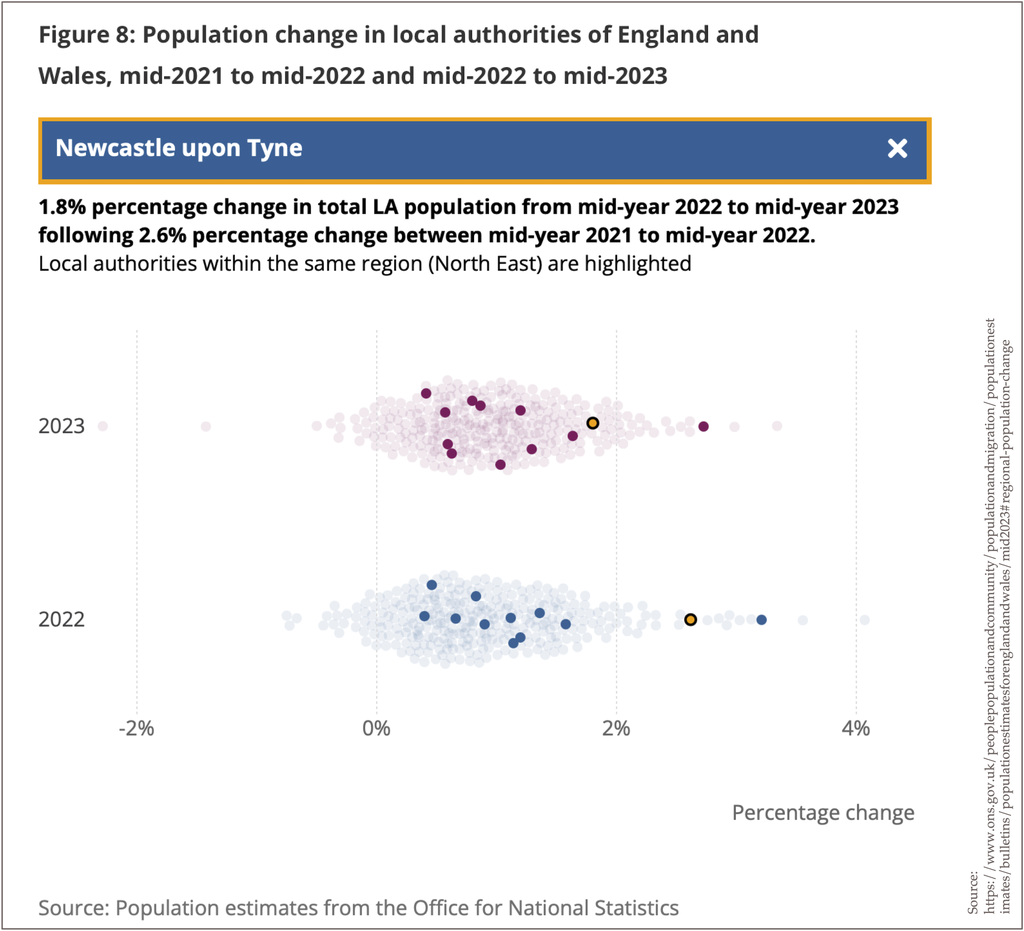

[figure not shown]

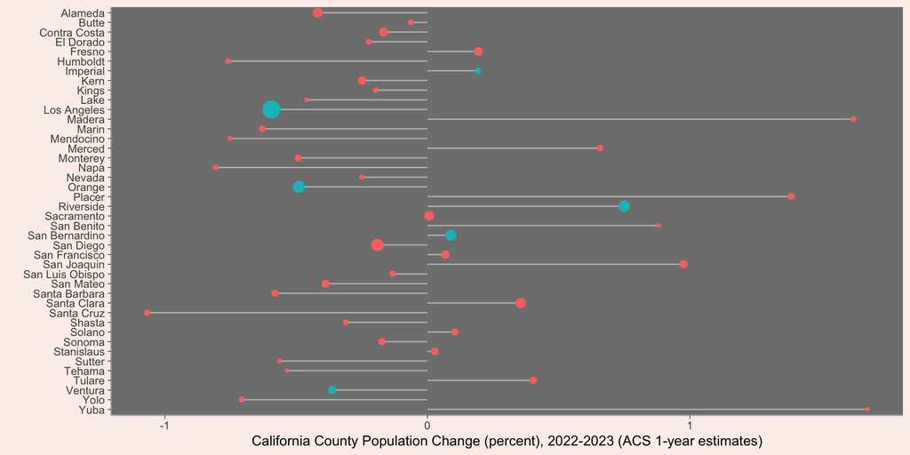

# Growth (and shrinkage) aren’t just *one* thing

## They’re the product of several inter-related processes

- Natural change (births and deaths)
- Internal migration (in-migrants and out-migrants)
- International migration (immigration…but also emigration!)
- Interstellar migration

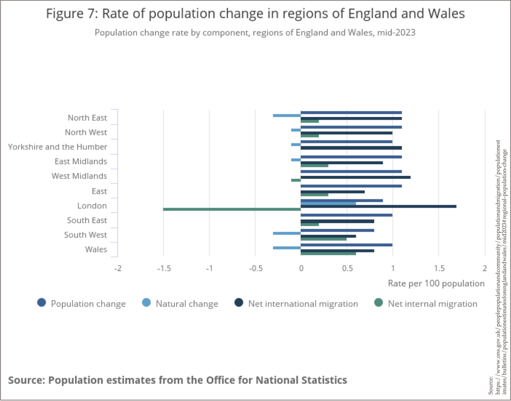

# And these processes matter for policy*

- Understanding the role of age structure
- And drivers of loss and growth (like, is it mostly age structure?)
- And constraints on demographic fulfillment, whether migration or fertility

* local, regional, *and* national

## Demographic changes are happening everywhere

- Low fertility (*below* replacement level, actually)
- Migration slowdowns
- Net out-migration
- Ageing

(and of course no place is a demographic island)

## Remember the successes that got us where we are

- Increased (healthy) life expectancy
- Contraception and choice
- Freedom of movement

# And some additional rules to guide us

1. No one stuck in place (at neighborhood or regional scale)
2. No one *forced* to move, either
3. Everyone able to achieve their desired family size
4. Caution about internal migration as a magic bullet
5. Emphasis on equality of opportunity

# So where does that leave us?

- Understanding non-demographic policies may have intended and unintended demographic consequences
  - *All* local and regional policy is demographic?
- Getting comfortable with a new demographic status quo
- Keeping in mind Southern California does not exist in a bubble
- Less focus on growth: creating quality not quantity
- More focus on well-being and quality of life

# Thank you and remember: don’t panic